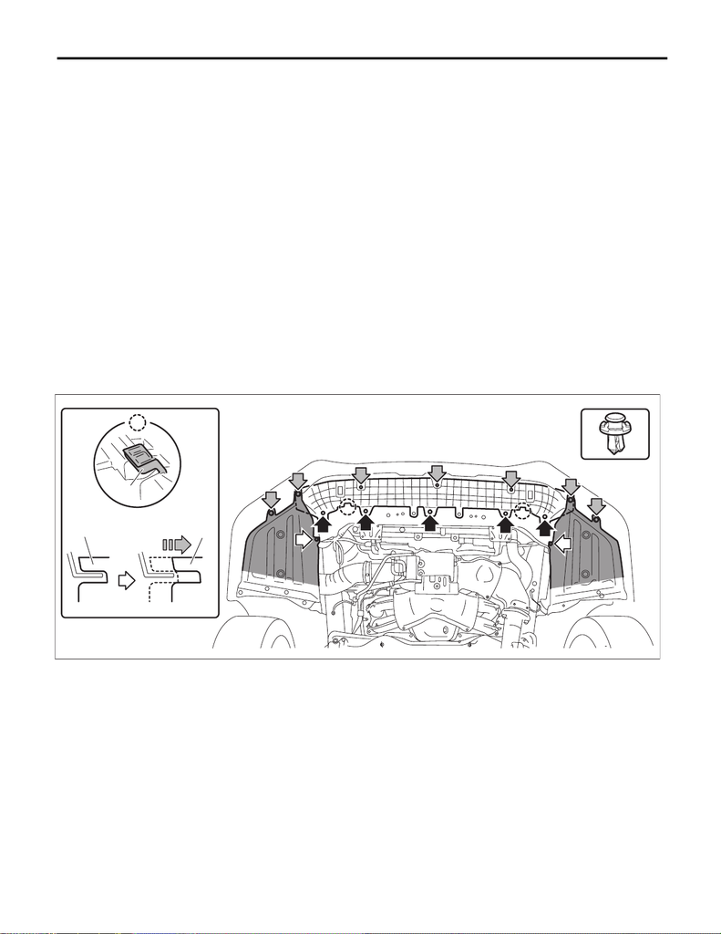

AC-50

Condenser

HVAC SYSTEM (HEATER, VENTILATOR AND A/C)

15.Condenser

A: REMOVAL

1) Using the refrigerant recovery system, discharge refrigerant. <Ref. to AC-26, PROCEDURE, Refrigerant

Recovery Procedure.>

2) Disconnect the ground cable from battery. <Ref. to NT-5, BATTERY, NOTE, Note.>

NOTE:

For models other than STI model, disconnect the ground terminal from battery sensor.

3) Remove the clips and remove the air intake duct.

• Except for STI model: <Ref. to IN(w/o STI)-22, REMOVAL, Air Intake Duct.>

• STI model: <Ref. to IN(STI)-11, REMOVAL, Air Intake Duct.>

4) Remove the reservoir tank.

• Except for STI model: <Ref. to CO(w/o STI)-52, REMOVAL, Reservoir Tank.>

• STI model: <Ref. to CO(STI)-27, REMOVAL, Reservoir Tank.>

5) Lift up the vehicle.

6) Remove the under cover - front. <Ref. to EI-21, REMOVAL, Front Under Cover.>

7) Remove the bracket – front center LWR.

(1) Remove the screw and clips, and turn over the mud guard - front.

(2) Remove the bolts and clips, and remove the bracket – front center LWR.

NOTE:

While entirely pushing the bracket – front center LWR forward, remove the two hooks (a) on the left and right.

AC-03585

(a)

(a)

(a)

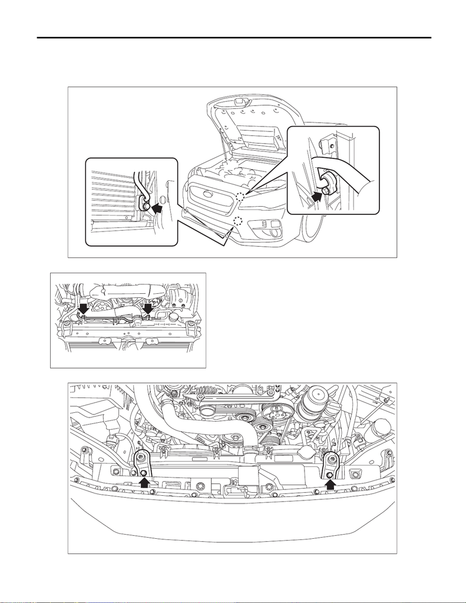

AC-51

Condenser

HVAC SYSTEM (HEATER, VENTILATOR AND A/C)

8) Remove the bolt, and detach the hose - pressure discharge and the pipe - evaporator cooling.

CAUTION:

Seal the disconnected hose, pipe and engaging part of condenser assembly with a plug or vinyl tape

to prevent foreign matter from entering.

9) Remove the bolts of the over flow pipe. (STI model)

10) Remove the bolts and remove the radiator upper bracket.

AC-03534

AC-03520

CO-03360

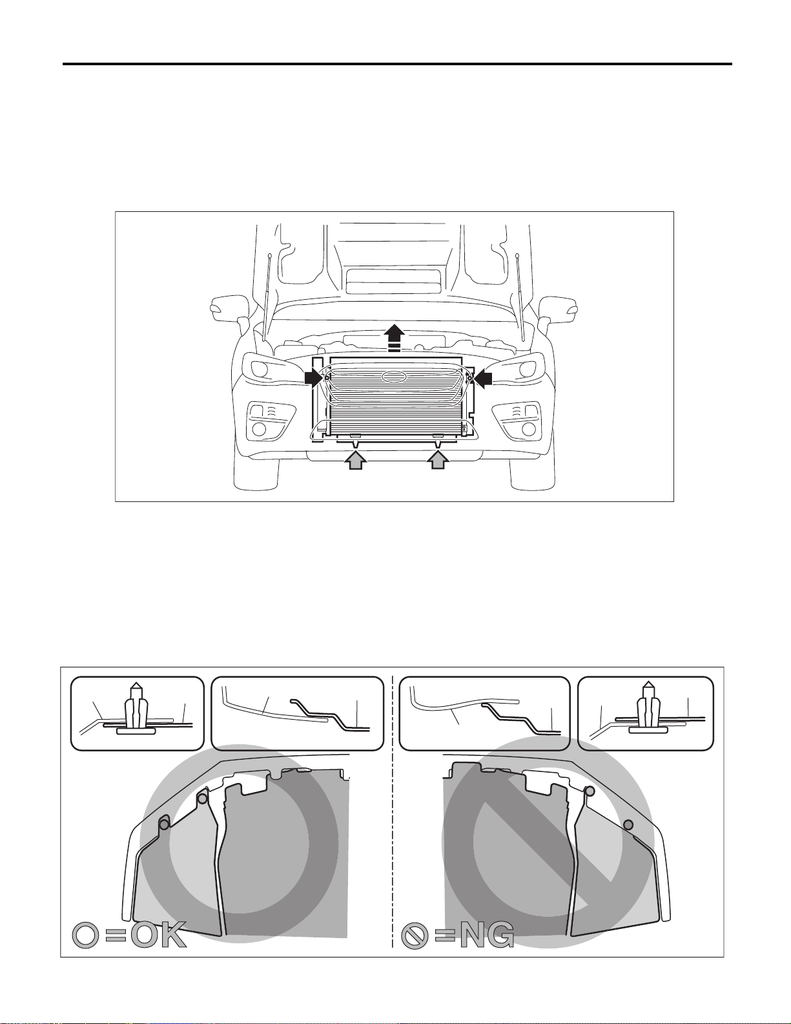

AC-52

Condenser

HVAC SYSTEM (HEATER, VENTILATOR AND A/C)

11) Remove the condenser assembly - air conditioner.

(1) Remove the bolt.

(2) Remove the lower guide, and remove the condenser assembly - air conditioner.

CAUTION:

• Push the radiator to the engine side, and pull it out through the space between the radiator and the

radiator panel.

• Be careful not to damage the condenser and radiator fin. If a damaged fin is found, repair it using

a thin screwdriver.

B: INSTALLATION

CAUTION:

• If the condenser assembly - air conditioner has been replaced, add an appropriate amount of com-

pressor oil. <Ref. to AC-34, ADJUSTMENT, Compressor Oil.>

• Replace the O-rings with new parts, and then apply compressor oil.

• Confirm that the lower guide of condenser assembly - air conditioner fits into the holes on radiator

panel.

• Install so that the front end of the under cover (b) comes inside the bumper face - front (a), and the

front end of the mud guard (c) comes outside the bumper face - front (a).

AC-03535

COM00138

(a)

(c)

(b)

(a)

(a)

(c)

(b)

(a)

[figure not shown]

AC-53

Condenser

HVAC SYSTEM (HEATER, VENTILATOR AND A/C)

1) Install the condenser assembly - air conditioner.

Tightening torque:

7.5 N·m (0.8 kgf-m, 5.5 ft-lb)

2) Install the radiator upper brackets.

Tightening torque:

12 N·m (1.2 kgf-m, 8.9 ft-lb)

3) Install the over flow pipe. (STI model)

Tightening torque:

7.5 N·m (0.8 kgf-m, 5.5 ft-lb)

4) Install the hose - pressure discharge and the pipe - evaporator cooling.

Tightening torque:

7.5 N·m (0.8 kgf-m, 5.5 ft-lb)

5) Install the bracket – front center LWR.

Tightening torque:

7.5 N·m (0.8 kgf-m, 5.5 ft-lb)

6) Install the under cover - front.

Tightening torque:

18 N·m (1.8 kgf-m, 13.3 ft-lb)

7) Lower the vehicle.

8) Install the reservoir tank.

9) Install the air intake duct.

10) Connect the battery ground terminal. <Ref. to NT-5, BATTERY, NOTE, Note.>

NOTE:

For models other than STI model, connect the ground terminal to battery sensor.

11) Charge refrigerant. <Ref. to AC-27, PROCEDURE, Refrigerant Charging Procedure.>

C: INSPECTION

1) Check to see that the condenser fins are not clogged with debris or insects. Blow with compressed air or

flush fins with water as needed.

2) If any oil leak is found, replace the condenser assembly - air conditioner.